# Lecture 12: Advanced Regressions & Stargazer Continued

### We’re going to cover:

Regression related:

- Panel (Fixed and Random Effects)
- Logit
- Margins

# Advanced Regressions

## Panel Data

There are a few packages out there that implement panel data models. We’ll cover two of them, plm() - an older frequently used package, and a newer package, fixest(). Another package to note is [lfe](https://cran.r-project.org/web/packages/lfe/index.html).

### Fixed Effects Models

Fixed effects models are equivalent to including dummy variables for the entity that you are following over time. You can include these dummy variables as factors (either for time or entity). However, that is computationally inefficient if you have some 1,500 people, for example. So, instead, we use the within transformation.

In plm() is an option for “within” - that is the fixed effects model. This is because you are taking differences within an entity.

Let’s use world bank data to apply the fixed effects model.

Let’s quickly clean this up a bit by renaming the columns. I’m going to leave in unnecessary columns since the data is not very large, but if I was working with a large dataframe, I’d drop it.

```
 [1] "iso2c"     "country"   "year"      "gdp"
 [5] "lfpart_f"  "pop"       "edu"       "iso3c"
 [9] "region"    "capital"   "longitude" "latitude"
[13] "income"    "lending"
```

Let’s great a baseline model regression with OLS:

Now, let’s run our model.

We need to tell plm what entity is being followed and what is the variable for time using the option index, and we need to tell plm what kind of model we are running.

Typically, the function is a class of regression methods and there will be an option for a specific estimation model. plm can be considered a package for panel data models and the estimation model is “within”

A one-way fixed effects model is like this:

```
Oneway (individual) effect Within Model

Call:
plm(formula = gdp ~ edu + income, data = wdi, model = "within",
    index = c("iso2c"))

Unbalanced Panel: n = 143, T = 1-16, N = 625

Residuals:
      Min.    1st Qu.     Median    3rd Qu.       Max.
-18.010710  -1.043567   0.050888   1.471418  18.722831

Coefficients:
     Estimate Std. Error t-value Pr(>|t|)
edu -0.131266   0.040749 -3.2213 0.001362 **
---
Signif. codes:  0 ‘***’ 0.001 ‘**’ 0.01 ‘*’ 0.05 ‘.’ 0.1 ‘ ’ 1

Total Sum of Squares:    6632.7
Residual Sum of Squares: 6492.7
R-Squared:      0.021118
Adj. R-Squared: -0.2699
F-statistic: 10.377 on 1 and 481 DF, p-value: 0.0013624
```

```
Oneway (individual) effect Within Model

Call:
plm(formula = gdp ~ edu + income, data = wdi, model = "within",
    index = c("iso2c", "year"))

Unbalanced Panel: n = 143, T = 1-16, N = 625

Residuals:
      Min.    1st Qu.     Median    3rd Qu.       Max.
-18.010710  -1.043567   0.050888   1.471418  18.722831

Coefficients:
     Estimate Std. Error t-value Pr(>|t|)
edu -0.131266   0.040749 -3.2213 0.001362 **
---
Signif. codes:  0 ‘***’ 0.001 ‘**’ 0.01 ‘*’ 0.05 ‘.’ 0.1 ‘ ’ 1

Total Sum of Squares:    6632.7
Residual Sum of Squares: 6492.7
R-Squared:      0.021118
Adj. R-Squared: -0.2699
F-statistic: 10.377 on 1 and 481 DF, p-value: 0.0013624
```

We can see the number of observations (N), the number of groups (n), how many units you have over time (T).

If you want to see the fixedeffects estimtates, you can do this with `fixef()`

```
     AD      AE      AL      AM      AO      AR      AU
16.4955 13.9220 16.2241 17.7271 11.3415  6.9866 15.9341
     AW      AZ      BA      BB      BD      BE      BF
12.7656 18.8625 10.7595 14.7235 19.1384 12.7509  6.8317
     BG      BH      BI      BN      BO      BR      BS
15.7259 12.2889  6.0111 14.6119 11.6052 20.8943 14.3602
     BT      BY      BZ      CD      CI      CL      CM
 7.5795 12.3605 12.4747 18.6485 14.1198 15.8478  8.7115
     CO      CR      CU      CV      CY      CZ      DE
15.4472 13.9534 13.2817  7.2017 12.3553 14.5051 17.1785
     DK      DM      DO      DZ      EC      EE      EG
12.5309 10.5669 13.8125 11.3385 13.8024 21.9514 16.3977
     ES      ET      FJ      FR      GE      GH      GM
13.8372 18.3822  9.0276 15.8396 17.2987 16.7713  8.7462
     GN      GR      GT      GY      HK      HN      HR
 6.1755 12.2559  9.0510  9.1890 14.8686 11.0279 12.7836
     HU      ID      IL      IN      IQ      IT      JM
15.9143 26.0195 15.5829 71.2511 18.6511 13.9384 13.6590
     JO      JP      KE      KG      KH      KR      KW
15.1810 22.0592 14.2689 14.7858 10.5588 18.1666 11.8537
     KY      KZ      LB      LI      LK      LS      LT
13.8071 17.6848 18.8597 14.7089  9.5664 10.4805 14.9895
     LU      LV      MD      ME      MH      MK      ML
19.6674 13.4357 15.3232 14.3321 10.8488 10.9316  7.3731
     MN      MO      MR      MT      MU      MV      MX
15.1641 22.5403  7.9541 18.1222 13.0994 30.7528 16.5836
     MY      MZ      NA      NE      NG      NL      NO
16.6469 11.4654  7.2106 13.0495 19.9620 13.5228 14.4060
     NP      OM      PA      PE      PH      PK      PL
 9.6284 11.0354 13.8773 16.3093 20.2716 17.6751 16.4486
     PR      PS      PT      PW      PY      QA      RO
12.3970 17.2988 11.0895  8.3294 12.3095 21.8516 15.3301
     RS      RU      RW      SA      SC      SE      SG
13.5017 23.3300 11.7114 14.6908 12.4071 14.6140 15.8800
     SI      SK      SL      SN      SR      ST      SV
13.1188 14.8009  9.4714  5.0113 16.1861 13.6101  8.8462
     SY      TD      TG      TH      TJ      TO      TR
12.9393 20.7523 10.3300 15.3451 20.1671 18.2352 19.2961
     TT      TZ      UA      UG      US      UY      VE
10.7833 14.5228 23.0828 12.4239 28.4145 14.6571 16.0119
     WS      ZA      ZW
17.1696 14.3776 12.7868
```

### fixest

You can run the same above regression with the package fixest using the function feols(). I’m mentioning this particular package because it is *insanely* fast. It can handle a huge amount of fixed effects where stata might break (unless you use reghdfe). It can support non-linear models, high-dimensional fixed effects, multiway clustering and a bunch of options that come in handy when you work with detailed data or big data. So, I want you to know it exists because of it’s flexibility in all things fixed effects.

Let’s try it. Rather than setting the fixed effects with an index, you’ll include the variables that are fixed after `|`

Let’s see what I mean here:

```
NOTE: 3,631 observations removed because of NA values (LHS: 249, RHS: 3,623).
Variables 'incomeHigh income', 'incomeLow income' and 2 others have been removed because of collinearity (see $collin.var).
```

```
OLS estimation, Dep. Var.: gdp
Observations: 625
Fixed-effects: country: 143,  year: 16
Standard-errors: Clustered (country)
```

|  | Estimate | Std. Error | t value | Pr(>\|t\|) |  |
| --- | --- | --- | --- | --- | --- |
| edu | -0.034933 | 0.049635 | -0.703797 | 0.48271 |  |

```
... 4 variables were removed because of collinearity (incomeHigh income, incomeLow income and 2 others [full set in $collin.var])
---
Signif. codes:  0 '***' 0.001 '**' 0.01 '*' 0.05 '.' 0.1 ' ' 1
RMSE: 2.66652     Adj. R2: 0.474238
                Within R2: 0.001482
```

Standard errors are already clustered by country automatically, but if you want standard errors, you can do so using summary and the option se

```
OLS estimation, Dep. Var.: gdp
Observations: 625
Fixed-effects: country: 143,  year: 16
Standard-errors: IID
```

|  | Estimate | Std. Error | t value | Pr(>\|t\|) |  |
| --- | --- | --- | --- | --- | --- |
| pop | 7.33000e-08 | 0.0000000495 | 1.482624 | 0.13885 |  |
| edu | -4.15886e-02 | 0.0421907646 | -0.985728 | 0.32478 |  |

```
---
Signif. codes:  0 '***' 0.001 '**' 0.01 '*' 0.05 '.' 0.1 ' ' 1
RMSE: 2.66024     Adj. R2: 0.475587
                Within R2: 0.00618
```

There might be time where you want to cluster your standard errors with specific items. You can also specify what you would like to cluster with the option cluster

```
OLS estimation, Dep. Var.: gdp
Observations: 625
Fixed-effects: country: 143,  year: 16
Standard-errors: Clustered (iso2c)
```

|  | Estimate | Std. Error | t value | Pr(>\|t\|) |  |
| --- | --- | --- | --- | --- | --- |
| pop | 7.33000e-08 | 0.0000000382 | 1.919725 | 0.056898 | . |
| edu | -4.15886e-02 | 0.0500759892 | -0.830510 | 0.407645 |  |

```
---
Signif. codes:  0 '***' 0.001 '**' 0.01 '*' 0.05 '.' 0.1 ' ' 1
RMSE: 2.66024     Adj. R2: 0.475587
                Within R2: 0.00618
```

### Random Effects Models

For plm, changing to a random effect model is pretty simple. You just need to change the option “model” to “random”

```
Oneway (individual) effect Random Effect Model
   (Swamy-Arora's transformation)

Call:
plm(formula = gdp ~ edu + income, data = wdi, model = "random",
    index = c("iso2c"))

Unbalanced Panel: n = 143, T = 1-16, N = 625

Effects:
                 var std.dev share
idiosyncratic 13.498   3.674 0.801
individual     3.350   1.830 0.199
theta:
   Min. 1st Qu.  Median    Mean 3rd Qu.    Max.
 0.1049  0.2916  0.4439  0.3852  0.4822  0.5515

Residuals:
    Min.  1st Qu.   Median     Mean  3rd Qu.     Max.
-17.8376  -1.6558  -0.0335  -0.0222   1.4962  23.3108

Coefficients:
                           Estimate Std. Error z-value
(Intercept)                7.392011   1.366726  5.4086
edu                       -0.046247   0.014376 -3.2169
incomeLow income           1.374375   1.232369  1.1152
incomeLower middle income  0.188481   0.803188  0.2347
incomeUpper middle income  0.479382   0.575059  0.8336
                           Pr(>|z|)
(Intercept)               6.354e-08 ***
edu                        0.001296 **
incomeLow income           0.264752
incomeLower middle income  0.814468
incomeUpper middle income  0.404494
---
Signif. codes:  0 ‘***’ 0.001 ‘**’ 0.01 ‘*’ 0.05 ‘.’ 0.1 ‘ ’ 1

Total Sum of Squares:    9355.5
Residual Sum of Squares: 8454
R-Squared:      0.096542
Adj. R-Squared: 0.090713
Chisq: 34.1486 on 4 DF, p-value: 6.9467e-07
```

There is something else called a mixed model where you might have both fixed effects and random effect parameters. This is particularly useful for nested datasets and when you might want to include fixed effects at one level and random effects for another variable. I’ve rarely seen it in economics papers, but it is often included in psychology models. I won’t discuss this indepthly, but [here](https://m-clark.github.io/mixed-models-with-R/introduction.html) is a website that explains how to apply it in R - although there are many out there and often people use the package [lmer()](https://rstudio-pubs-static.s3.amazonaws.com/63556_e35cc7e2dfb54a5bb551f3fa4b3ec4ae.html).

#### Hausman Taylor test

You may know that when deciding between random or fixed effects models, you have to ensure that the random variables do not correlate with your independent variables. Frequently, this assumption is broken and is why most people use fixed effects models. However, we often want to test between our fixed or random effect model. We do this with the `phtest()` function in plm.

```
    Hausman Test

data:  gdp ~ edu + income
chisq = 4.9719, df = 1, p-value = 0.02576
alternative hypothesis: one model is inconsistent
```

There are a variety of tests for serial correlation, heteroskedasticity, random effects (if you should include random effects compared to an ols model, stationarity/unit roots, etc). These are outlined in the vignettes of plm and you can explore them further on your own.

## Logit/Probit

Logit/probit models can be run using the generalized linear model packages `glm()` You identify a logit or probit model using the option “family”. You need to specify the link function to distinguish between a logit or probit model.

A good introduction to logit models (and many other applied econometric models) can be found at UCLA’s website [here](https://stats.idre.ucla.edu/r/dae/logit-regression/) and for probit models [here](https://stats.idre.ucla.edu/r/dae/probit-regression/)

Let’s start with a logit model:

```
 [1] "smoker"   "smkban"   "age"      "hsdrop"   "hsgrad"
 [6] "colsome"  "colgrad"  "black"    "hispanic" "female"

Call:
glm(formula = smoker ~ age + female + hsdrop + hsgrad + colsome +
    colgrad, family = "binomial", data = smoking)

Deviance Residuals:
    Min       1Q   Median       3Q      Max
-1.0622  -0.8203  -0.5884  -0.4056   2.2899

Coefficients:
             Estimate Std. Error z value Pr(>|z|)
(Intercept) -1.940401   0.135308 -14.341  < 2e-16 ***
age         -0.005998   0.001964  -3.054 0.002256 **
female      -0.210057   0.048467  -4.334 1.46e-05 ***
hsdrop       1.771164   0.126802  13.968  < 2e-16 ***
hsgrad       1.521847   0.113672  13.388  < 2e-16 ***
colsome      1.161500   0.116063  10.007  < 2e-16 ***
colgrad      0.424145   0.125638   3.376 0.000736 ***
---
Signif. codes:  0 ‘***’ 0.001 ‘**’ 0.01 ‘*’ 0.05 ‘.’ 0.1 ‘ ’ 1

(Dispersion parameter for binomial family taken to be 1)

    Null deviance: 11074  on 9999  degrees of freedom
Residual deviance: 10583  on 9993  degrees of freedom
AIC: 10597

Number of Fisher Scoring iterations: 4
```

The probit model just needs a tweak in the link function within the option “family”, and that is set like this:

```
Call:
glm(formula = smoker ~ age + female + hsdrop + hsgrad + colsome +
    colgrad, family = binomial(link = "probit"), data = smoking)

Deviance Residuals:
    Min       1Q   Median       3Q      Max
-1.0563  -0.8214  -0.5919  -0.4005   2.3070

Coefficients:
             Estimate Std. Error z value Pr(>|z|)
(Intercept) -1.125266   0.073137 -15.386  < 2e-16 ***
age         -0.003458   0.001157  -2.990 0.002791 **
female      -0.123336   0.028445  -4.336 1.45e-05 ***
hsdrop       1.005005   0.068663  14.637  < 2e-16 ***
hsgrad       0.851358   0.059047  14.418  < 2e-16 ***
colsome      0.637198   0.060379  10.553  < 2e-16 ***
colgrad      0.220119   0.064848   3.394 0.000688 ***
---
Signif. codes:  0 ‘***’ 0.001 ‘**’ 0.01 ‘*’ 0.05 ‘.’ 0.1 ‘ ’ 1

(Dispersion parameter for binomial family taken to be 1)

    Null deviance: 11074  on 9999  degrees of freedom
Residual deviance: 10584  on 9993  degrees of freedom
AIC: 10598

Number of Fisher Scoring iterations: 4
```

Marginal effects can’t be read directly from the output. You need to apply the link function to interpret the results (though the sign and standard error can be interpreted as usual).

This is why the margins function is so important! Margins works with other regressions, as well.

## Margins

The margins package is quite similar to the margins package in STATA. You can apply interpretation to a wide variety of regressions - logit/probit, but also non-linear terms in OLS models. You can check out more examples and features in its vignette [here](https://cran.r-project.org/web/packages/margins/vignettes/Introduction.html).

The package makes it easy to calculate values and plot them.

When we use `margins(model_name)` it will give us the *average* marginal effect for each variable

And we can plot it quit easily:

[figure not shown]

To get the partial effect at the mean (or at any particular value), we us the at option:

Here we specify a range of numbers

```
Average marginal effects at specified values
glm(formula = smoker ~ age + female + hsdrop + hsgrad + colsome +     colgrad, family = "binomial", data = smoking)
```

| at(age) | age |
| --- | --- |
| 18 | -0.0011098781 |
| 40 | -0.0010466630 |
| 60 | -0.0009870808 |

Or at the mean of age

```
Average marginal effects at specified values
glm(formula = smoker ~ age + female + hsdrop + hsgrad + colsome +     colgrad, family = "binomial", data = smoking)
```

| at(age) | age |
| --- | --- |
| 38.6932 | -0.001050497 |

### Marignal effects for non-linear terms in OLS

The margins package can also be used to get the marginal effects for non-linear terms in OLS models - often these are interactions or polynomial functions. Let’s take an example of a model with the squared term population.

Notice that to square a term I use “^2” and the “I()” to indicate that it’s a second order term.

```
Call:
lm(formula = gdp ~ lfpart_f + pop + I(pop^2), data = wdi)

Residuals:
    Min      1Q  Median      3Q     Max
-65.787  -2.051   0.003   2.061 119.426

Coefficients:
              Estimate Std. Error t value Pr(>|t|)
(Intercept)  3.281e+00  2.993e-01  10.964  < 2e-16 ***
lfpart_f     1.250e-02  5.594e-03   2.234 0.025541 *
pop          1.289e-09  2.510e-10   5.134 2.98e-07 ***
I(pop^2)    -1.836e-19  4.822e-20  -3.807 0.000143 ***
---
Signif. codes:  0 ‘***’ 0.001 ‘**’ 0.01 ‘*’ 0.05 ‘.’ 0.1 ‘ ’ 1

Residual standard error: 5.109 on 3636 degrees of freedom
  (616 observations deleted due to missingness)
Multiple R-squared:  0.01023,   Adjusted R-squared:  0.009412
F-statistic: 12.53 on 3 and 3636 DF,  p-value: 3.807e-08
```

Let’s apply marginal effect to population. We can take the marginal effect of any particular value of population that we are interested in.

```
Average marginal effects at specified values
lm(formula = gdp ~ lfpart_f + pop + I(pop^2), data = wdi)
```

| at(pop) | lfpart_f | pop |
| --- | --- | --- |
| 270879632 | 0.01249749 | 1.189148e-09 |

We can combine those two lines of code into one (and not save the value of the mean of population that will take up RAM)

```
Average marginal effects at specified values
lm(formula = gdp ~ lfpart_f + pop + I(pop^2), data = wdi)
```

| at(pop) | lfpart_f | pop |
| --- | --- | --- |
| 270879632 | 0.01249749 | 1.189148e-09 |

We can input a list of values rather than just one value

```
Average marginal effects at specified values
lm(formula = gdp ~ lfpart_f + pop + I(pop^2), data = wdi)
```

| at(pop) | lfpart_f | pop |
| --- | --- | --- |
| 1e+06 | 0.01249749 | 1.288224e-09 |
| 5e+06 | 0.01249749 | 1.286756e-09 |
| 9e+06 | 0.01249749 | 1.285287e-09 |

It’s far better to use numbers relevant to the value/data that exists. We can use a bunch of summary statistics instead of just one to see the marginal effects of population. Turkey’s 5 numbers include min, lower hinge, median, upper hinge and maximum - the function is called `fivenum()`

Looking at the marginal effects, you can see that the labor force participation of women is constant (as expected), but population marginal effects depend on the value of population - there seems to be a non-linear relationship.

```
[1]       9392    1336126    9088884   58056732 7339076654
```

```
A 'at' value for 'pop' is outside observed data range (97962,7339076654)!Average marginal effects at specified values
lm(formula = gdp ~ lfpart_f + pop + I(pop^2), data = wdi)
```

| at(pop) | lfpart_f | pop |
| --- | --- | --- |
| 9392 | 0.01249749 | 1.288588e-09 |
| 1336126 | 0.01249749 | 1.288101e-09 |
| 9088884 | 0.01249749 | 1.285255e-09 |
| 58056732 | 0.01249749 | 1.267278e-09 |
| 7339076654 | 0.01249749 | -1.405667e-09 |

And we can also graph the marginal effect of population with `cplot()`

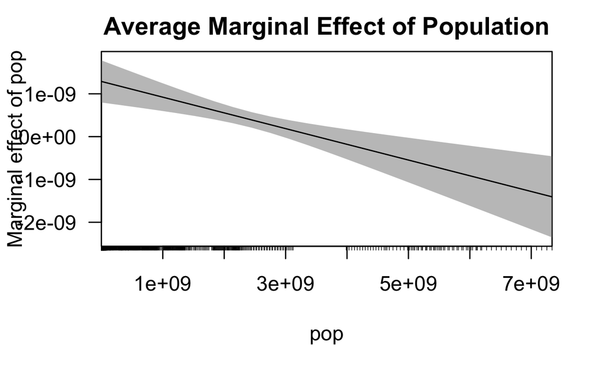

### Stargazer (Again)

Let’s show some models side by side

[output not shown]

[output not shown]